# Präsentationen mit artemisia

itbayer

Juni 2013 -

# Punkt 1

- ich
- will
- euch
- zeigen

# punkt 2

wie einfach man eine Präsentation

- erstellen
- kann

# artemisai ...

ist ein kleines Framework mit dem man eine Präsentation im HTML Format erstellen kann.

## Der Name Artemisia

> Artemisia ist der Gattungsname des Beifußes. Benannt nach der Göttin Artemis, der Heil und Leben spendenden Erdenmutter. Der Beifuß gilt von alters her als heilig. Als 'Mariens Bettstroh' wird er mit der Mutter Gottes in Zusammenhang gebracht, die das Himmlische mit dem Irdischen verbindet.

Auszug aus der Seite artemisa.de.

# artemisai ist einfach weil ...

man nicht die Eigenheiten eines Programmes erlernen muss.

- Texte schreiben im markdown Format
- make

Fertig.

# artemisai ist portabel weil ...

für die Darstellung ein Internet Browser ausreicht.

# artemisai ist kompakt weil ...

alle Teile der Präsentation im einer HTML Datei gespeichert werden.

# Eckpunkte

- Erstellen
  - jeder Texteditor
  - Programme
    - pandoc
    - imagemagick (optional)
    - (g)vim (optional)
- Formatierung
  - markdown (pandocs markdown)
- Präsentieren
  - HTML Browser

# Steuerung

Die Steuerung von Artemisia übernimmt `make`.

- make
  - make start.html
- make pdf
  - make start.pdf
- make clean
- make show

# Layout

Das Layout von artemisai wurde schlicht und einfach gehalten.

Auf der Titelseite und in den einzelnen Folien kann jeweils eine Hintergrund Grafik eingebunden werden.

- `css/style.css`
- `css/titlepage.png`
  - `css/titlepage.xcf`
- `css/level1.png`
  - `css/level1.xcf`
- `template/slidy.template`

## Layout Erweiterung

Einfache Erweiterung durch CSS.

###### Anmerkung

Hier ist die Anmerkung der ersten Seite die mit einer Überschrift 6 eingeleitet wurde.

# Bilder

Alle Bilder die sich im `fig` Verzeichnis befinden werden mittels ImageMagick angepasst.

# Bedienung der Präsentatin

**Vollbild Modus**

Der Vollbildmodus wird über den Browser bereitgestellt, Taste F11.

## Navigation

**Seite weiter**

- Maus Klick
- Leertaste
- Cursor rechts
- Bild runter

**Seite zurück**

- Cursor links
- Bild hoch

## Darstellung

**Schriftgröße (b), (s), (<), (>)**

Die Schriftgröße wird automatisch angepasst, je nach Fenster Größe. Sie kann aber auch manuell angepasst werden.

- Taste > oder *b*<sup>big</sup> Schrift größer
- Taste < oder *s*<sup>small</sup> Schrift kleiner

**Statuszeile ein -ausschalten (F)**

Mit der Taste F kann die Statuszeile ausgeschaltet werden.

## Sonstigen

**Maus deaktivieren (K)**

Mit der Taste K wird die Maus zum weiter schalten einer Folie aus -eingeschaltet.

**Inhaltsverzeichnis (C)**

Mit der Taste C kann das Inhaltsverzeichnis eingeblendet werden. Mit jeder anderen Taste kann es wieder ausgeblendet werden.

# Anmerkung in der Präsentation

- Anmerkungen werden mit `###{.anmerkung}` eingeleitet.
- Anmerkungen müssen am Ende einer Folie stehen
- Anmerkungen werden im HTML Format ausgeblendet
- Anmerkungen werden im PDF Format **nicht** ausgeblendet

## Beispiel Anmerkung

```
 Überschrift
 ===========

 Hier ist der normale Text

 - eins
 - zwei
 - drei

 ###{.anmerkung}

 Nicht vergessen zu erwähnen dass ...
```

# Artemisia mit gvim

Über das Script `./start.sh` startet der Editor gvim mit einer Artemisia Menü Erweiterung.

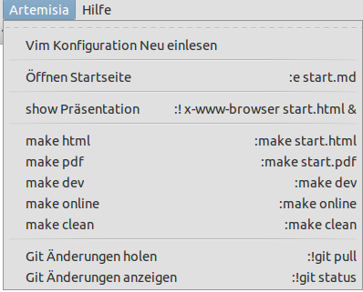

Abbildung: Das Artemisia gvim Menü

# Was geht nicht

- Fusszeilen

Formatierung die in der Präsentation nicht umgesetzt, unterstützt werden.

Besten Dank für Interesse

# Anhang

Einzelen Datei von github.com runter laden

```
https://raw.github.com/itbayer/artemisai/master/DATEI
```

Bilder mit dia dia -s 700x -e diabild.png diafile.dia

**-s**

breite x höhe. wird einer weg gelassen wird der andere automatisch berechnet

**-e**

exportieren